# Riders' characteristics affecting the trip durations in Ford Gobike Dataset

## by AbdelRahman Emam

## Investigation Overview

For this investigation, we want to find out how some features may effect the trip durations. Our main focus will be on: 'member_age', 'user_type', and 'member_gender' features.

## Dataset Overview

There are 183,412 Ford goBike rides in this dataset. The dataset has, initially, 16 features, such as:

1. **Numerical features:**  
   duration_sec, start_station_id, start_station_latitude, start_station_longitude, end_station_id, end_station_latitude, end_station_longitude, bike_id, and member_birth_year
2. **Categorical (object-typed) features:**  
   user_type, member_gender, start_station_name, and end_station_name
3. **Datetime features:**  
   start_time and end_time
4. **Boolean features:**  
   bike_share_for_all_trip

## Trip Duration vs Member Age

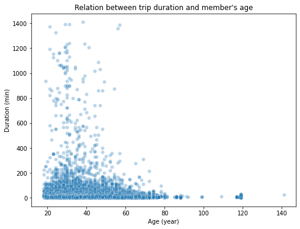

Durations are mostly below 400 minutes and age below 80 years.

Let's focus the plot on these ranges.

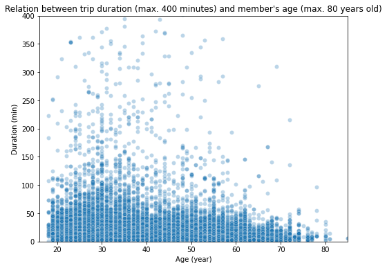

Trip duration depends on the member's age. Members aged between **30** and **40** years old have higher percentage of taking longer rides compared to other age ranges. While getting older, members are getting to take shorter rides. I can't tell that wasn't expected. As people age up, they can't do the same effort as before.

## Trip Duration vs Member Gender

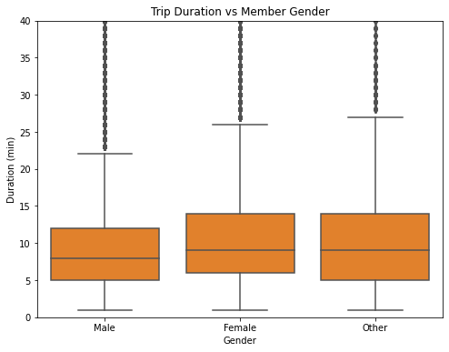

Although the number of male riders are much more than female or others, the average of trip durations of males is lower than both of them.

## Trip Duration vs User Type

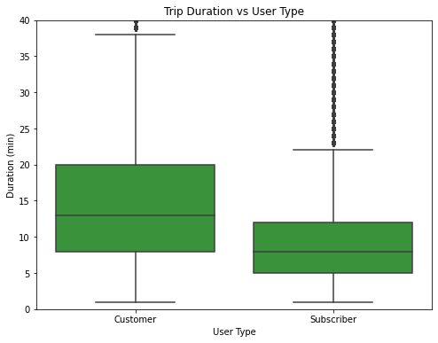

We can observe that customers are more likely to have longer trips compared to subscribers.

## Trip Duration vs Member's age, for different member's gender

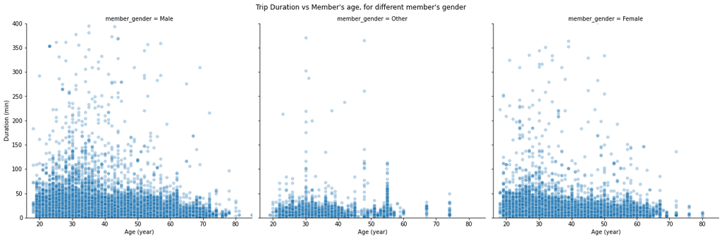

Surprisingly, 'Other' gender has another peak of trip durations for riders aged between 55~60 years old.

## Trip Duration vs Member's age, for different user type

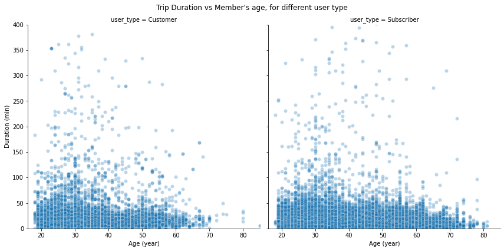

Both 'Customer' and 'Subscriber' types almost have the same trend.

## Conclusion

Trip duration depends on the member's age. Members aged between **30** and **40** years old have higher percentage of taking longer rides compared to other age ranges. While getting older, members are getting to take shorter rides. I can't tell that wasn't expected. As people age up, they can't do the same effort as before.

'Male' gender doesn't have higher trip duration than 'Female' and 'Other', as it may be expected. Surprisingly,'Others' gender aged between 55~60 years old have high trip durations.